# Programming with R

Analyzing multiple data sets

## Learning Objectives

> - Explain what a `for` loop does.
> - Correctly write `for` loops to repeat simple calculations.
> - Trace changes to a loop variable as the loop runs.
> - Trace changes to other variables as they are updated by a `for` loop.
> - Use a function to get a list of filenames that match a simple pattern.
> - Use a `for` loop to process multiple files.

We have created a function called `analyze` that creates graphs of the minimum, average, and maximum daily inflammation rates for a single data set:

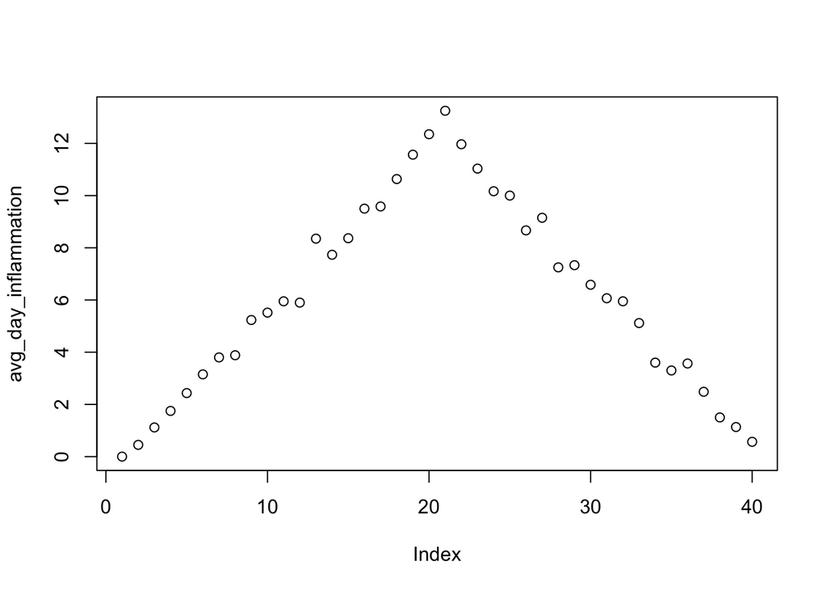

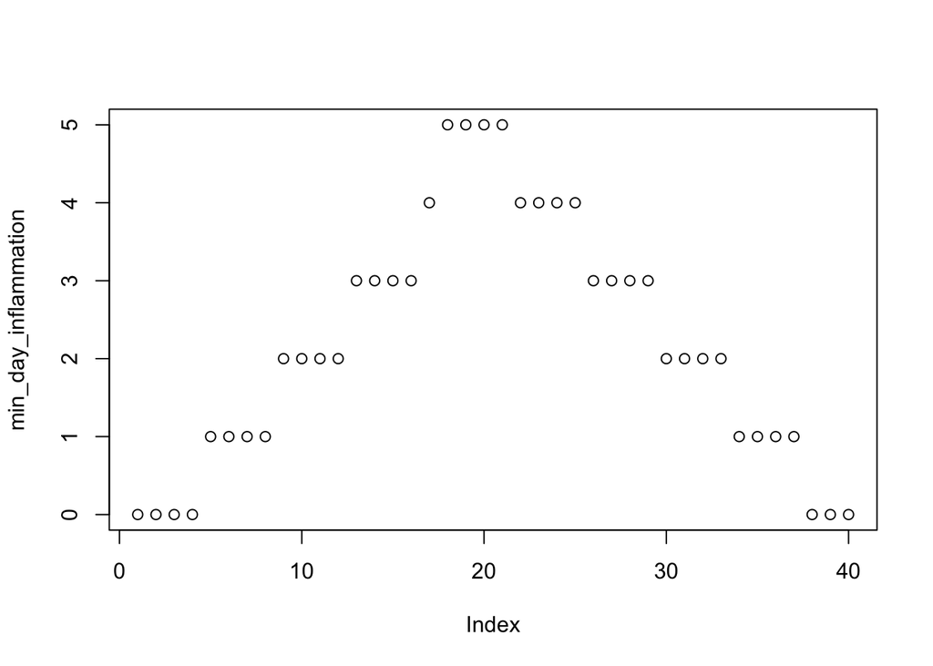

```r
analyze <- function(filename) {
  # Plots the average, min, and max inflammation over time.
  # Input is character string of a csv file.
  dat <- read.csv(file = filename, header = FALSE)
  avg_day_inflammation <- apply(dat, 2, mean)
  plot(avg_day_inflammation)
  max_day_inflammation <- apply(dat, 2, max)
  plot(max_day_inflammation)
  min_day_inflammation <- apply(dat, 2, min)
  plot(min_day_inflammation)
}

analyze("data/inflammation-01.csv")
```

[output not shown]

We can use it to analyze other data sets one by one:

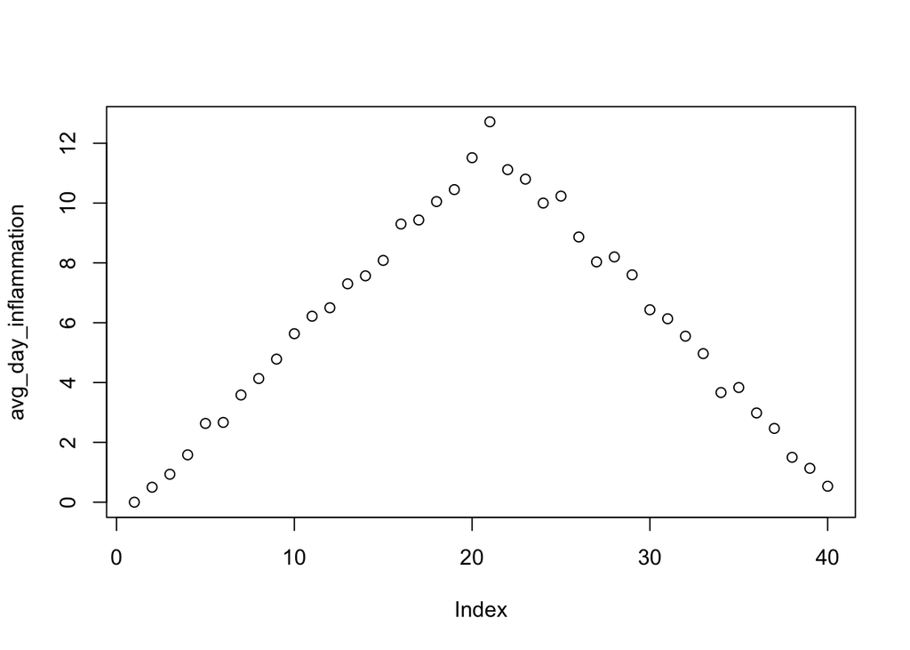

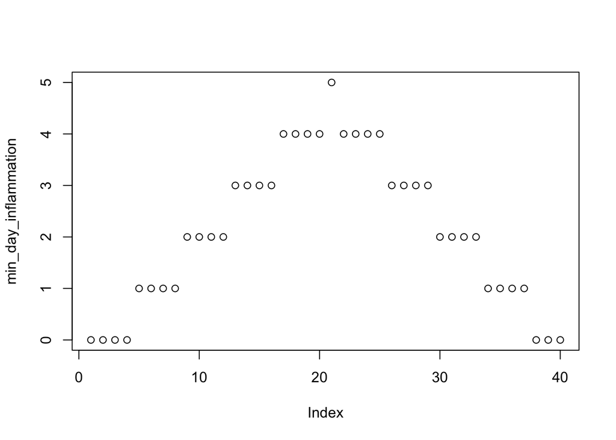

```r
analyze("data/inflammation-02.csv")
```

[output not shown]

but we have a dozen data sets right now and more on the way. We want to create plots for all our data sets with a single statement. To do that, we’ll have to teach the computer how to repeat things.

### For Loops

Suppose we want to print each word in a sentence. One way is to use six `print` statements:

```r
best_practice <- c("Let", "the", "computer", "do", "the", "work")
print_words <- function(sentence) {
  print(sentence[1])
  print(sentence[2])
  print(sentence[3])
  print(sentence[4])
  print(sentence[5])
  print(sentence[6])
}

print_words(best_practice)
```

```
## [1] "Let"
## [1] "the"
## [1] "computer"
## [1] "do"
## [1] "the"
## [1] "work"
```

but that’s a bad approach for two reasons:

1. It doesn’t scale: if we want to print the elements in a vector that’s hundreds long, we’d be better off just typing them in.
2. It’s fragile: if we give it a longer vector, it only prints part of the data, and if we give it a shorter input, it returns `NA` values because we’re asking for elements that don’t exist!

```r
best_practice[-6]
```

```
## [1] "Let"      "the"      "computer" "do"       "the"
```

```r
print_words(best_practice[-6])
```

```
## [1] "Let"
## [1] "the"
## [1] "computer"
## [1] "do"
## [1] "the"
## [1] NA
```

## Tip

> R has has a special variable, `NA`, for designating missing values that are **N**ot **A**vailable in a data set. See `?NA` and [An Introduction to R](http://cran.r-project.org/doc/manuals/r-release/R-intro.html#Missing-values) for more details.

Here’s a better approach:

```r
print_words <- function(sentence) {
  for (word in sentence) {
    print(word)
  }
}

print_words(best_practice)
```

```
## [1] "Let"
## [1] "the"
## [1] "computer"
## [1] "do"
## [1] "the"
## [1] "work"
```

This is shorter—certainly shorter than something that prints every character in a hundred-letter string—and more robust as well:

```r
print_words(best_practice[-6])
```

```
## [1] "Let"
## [1] "the"
## [1] "computer"
## [1] "do"
## [1] "the"
```

The improved version of `print_words` uses a for loop to repeat an operation—in this case, printing—once for each thing in a collection. The general form of a loop is:

```r
for (variable in collection) {
  do things with variable
}
```

We can name the loop variable anything we like (with a few [restrictions](http://cran.r-project.org/doc/manuals/R-intro.html#R-commands_003b-case-sensitivity-etc), e.g. the name of the variable cannot start with a digit). `in` is part of the `for` syntax. Note that the body of the loop is enclosed in curly braces `{ }`. For a single-line loop body, as here, the braces aren’t needed, but it is good practice to include them as we did.

Here’s another loop that repeatedly updates a variable:

```r
len <- 0
vowels <- c("a", "e", "i", "o", "u")
for (v in vowels) {
  len <- len + 1
}
# Number of vowels
len
```

```
## [1] 5
```

It’s worth tracing the execution of this little program step by step. Since there are five elements in the vector `vowels`, the statement inside the loop will be executed five times. The first time around, `len` is zero (the value assigned to it on line 1) and `v` is `"a"`. The statement adds 1 to the old value of `len`, producing 1, and updates `len` to refer to that new value. The next time around, `v` is `"e"` and `len` is 1, so `len` is updated to be 2. After three more updates, `len` is 5; since there is nothing left in the vector `vowels` for R to process, the loop finishes.

Note that a loop variable is just a variable that’s being used to record progress in a loop. It still exists after the loop is over, and we can re-use variables previously defined as loop variables as well:

```r
letter <- "z"
for (letter in c("a", "b", "c")) {
  print(letter)
}
```

```
## [1] "a"
## [1] "b"
## [1] "c"
```

```r
# after the loop, letter is
letter
```

```
## [1] "c"
```

Note also that finding the length of a vector is such a common operation that R actually has a built-in function to do it called `length`:

```r
length(vowels)
```

```
## [1] 5
```

`length` is much faster than any R function we could write ourselves, and much easier to read than a two-line loop; it will also give us the length of many other things that we haven’t met yet, so we should always use it when we can (see this lesson to learn more about the different ways to store data in R).

## Challenge - Using loops

> 1. R has a built-in function called `seq` that creates a list of numbers:

> ```r
> seq(3)
> ```

> ```
> ## [1] 1 2 3
> ```

> Using `seq`, write a function that prints the first **N** natural numbers, one per line:

> ```r
> print_N(3)
> ```

> ```
> ## [1] 1
> ## [1] 2
> ## [1] 3
> ```

> 2. Write a function called `total` that calculates the sum of the values in a vector. (R has a built-in function called `sum` that does this for you. Please don’t use it for this exercise.)

> ```r
> ex_vec <- c(4, 8, 15, 16, 23, 42)
> total(ex_vec)
> ```

> ```
> ## [1] 108
> ```

> 3. Exponentiation is built into R:

> ```r
> 2^4
> ```

> ```
> ## [1] 16
> ```

> Write a function called `expo` that uses a loop to calculate the same result.

> ```r
> expo(2, 4)
> ```

> ```
> ## [1] 16
> ```

### Processing Multiple Files

We now have almost everything we need to process all our data files. The only thing that’s missing is a function that finds files whose names match a pattern. We do not need to write it ourselves because R already has a function to do this called `list.files`.

If we run the function without any arguments, `list.files()`, it returns every file in the current working directory. We can understand this result by reading the help file (`?list.files`). The first argument, `path`, is the path to the directory to be searched, and it has the default value of `"."` (recall from the [lesson](http://swcarpentry.github.io/shell-novice/01-filedir.html) on the Unix Shell that `"."` is shorthand for the current working directory). The second argument, `pattern`, is the pattern being searched, and it has the default value of `NULL`. Since no pattern is specified to filter the files, all files are returned.

So to list all the csv files, we could run either of the following:

```r
list.files(path = "data", pattern = "csv")
```

```
##  [1] "beeOperations.csv"   "inflammation-01.csv" "inflammation-02.csv"
##  [4] "inflammation-03.csv" "inflammation-04.csv" "inflammation-05.csv"
##  [7] "inflammation-06.csv" "inflammation-07.csv" "inflammation-08.csv"
## [10] "inflammation-09.csv" "inflammation-10.csv" "inflammation-11.csv"
## [13] "inflammation-12.csv" "small-01.csv"        "small-02.csv"
## [16] "small-03.csv"
```

```r
list.files(path = "data", pattern = "inflammation")
```

```
##  [1] "inflammation-01.csv" "inflammation-02.csv" "inflammation-03.csv"
##  [4] "inflammation-04.csv" "inflammation-05.csv" "inflammation-06.csv"
##  [7] "inflammation-07.csv" "inflammation-08.csv" "inflammation-09.csv"
## [10] "inflammation-10.csv" "inflammation-11.csv" "inflammation-12.csv"
```

## Tip

> For larger projects, it is recommended to organize separate parts of the analysis into multiple subdirectories, e.g. one subdirectory for the raw data, one for the code, and one for the results like figures. We have done that here to some extent, putting all of our data files into the subdirectory “data”. For more advice on this topic, you can read [A quick guide to organizing computational biology projects](http://www.ploscompbiol.org/article/info%3Adoi%2F10.1371%2Fjournal.pcbi.1000424) by William Stafford Noble.

As these examples show, `list.files` result is a vector of strings, which means we can loop over it to do something with each filename in turn. In our case, the “something” we want is our `analyze` function.

Because we have put our data in separate subdirectory, if we want to access these files using the output of `list.files` we also need to include the “path” portion of the file name. We can do that by using the argument `full.names = TRUE`.

```r
list.files(path = "data", pattern = "csv", full.names = TRUE)
```

```
##  [1] "data/beeOperations.csv"   "data/inflammation-01.csv"
##  [3] "data/inflammation-02.csv" "data/inflammation-03.csv"
##  [5] "data/inflammation-04.csv" "data/inflammation-05.csv"
##  [7] "data/inflammation-06.csv" "data/inflammation-07.csv"
##  [9] "data/inflammation-08.csv" "data/inflammation-09.csv"
## [11] "data/inflammation-10.csv" "data/inflammation-11.csv"
## [13] "data/inflammation-12.csv" "data/small-01.csv"
## [15] "data/small-02.csv"        "data/small-03.csv"
```

```r
list.files(path = "data", pattern = "inflammation", full.names = TRUE)
```

```
##  [1] "data/inflammation-01.csv" "data/inflammation-02.csv"
##  [3] "data/inflammation-03.csv" "data/inflammation-04.csv"
##  [5] "data/inflammation-05.csv" "data/inflammation-06.csv"
##  [7] "data/inflammation-07.csv" "data/inflammation-08.csv"
##  [9] "data/inflammation-09.csv" "data/inflammation-10.csv"
## [11] "data/inflammation-11.csv" "data/inflammation-12.csv"
```

Let’s test out running our `analyze` function by using it on the first three files in the vector returned by `list.files`:

```r
filenames <- list.files(path = "data", pattern = "inflammation", full.names = TRUE)
filenames <- filenames[1:3]
for (f in filenames) {
  print(f)
  analyze(f)
}
```

[output not shown]

```
## [1] "data/inflammation-01.csv"
```

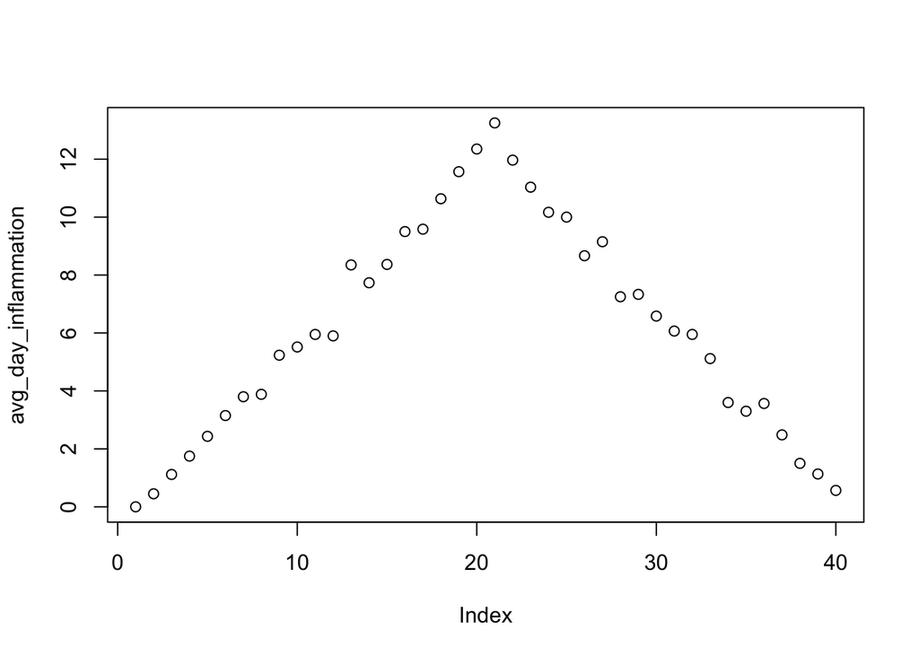

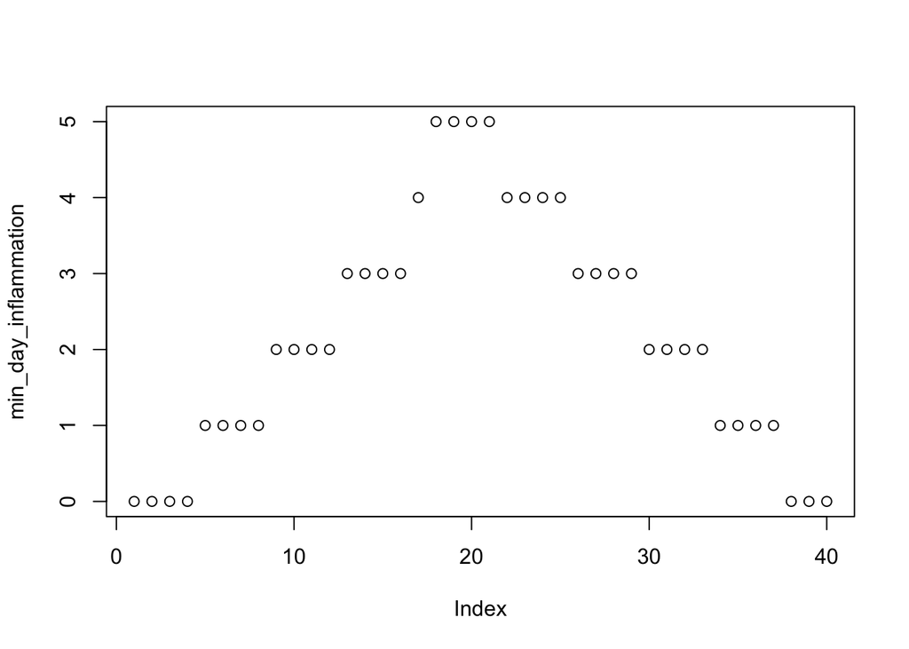

```
## [1] "data/inflammation-02.csv"
```

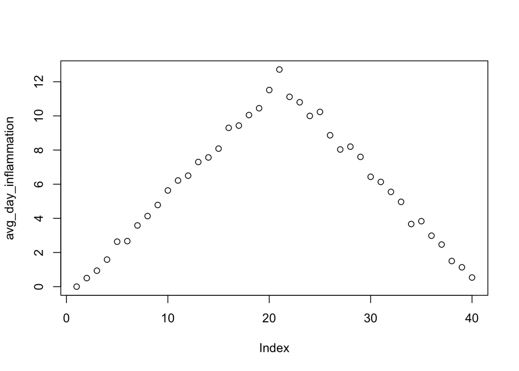

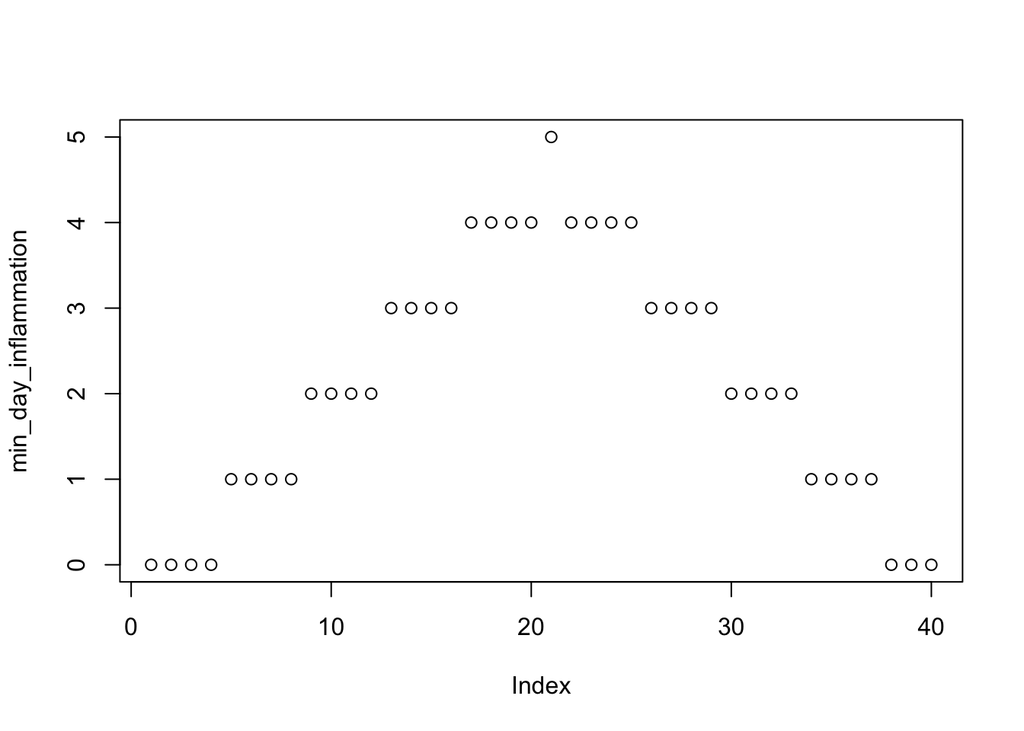

```
## [1] "data/inflammation-03.csv"
```

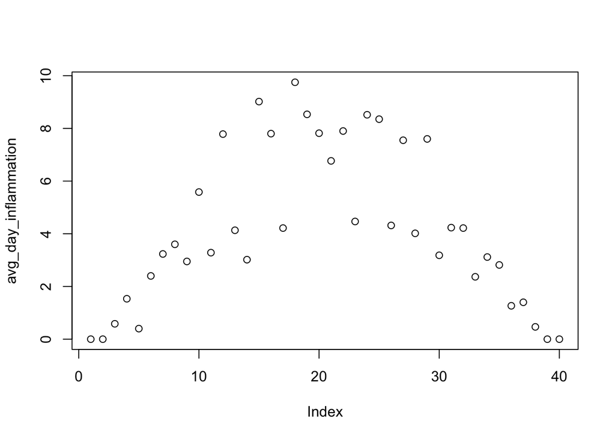

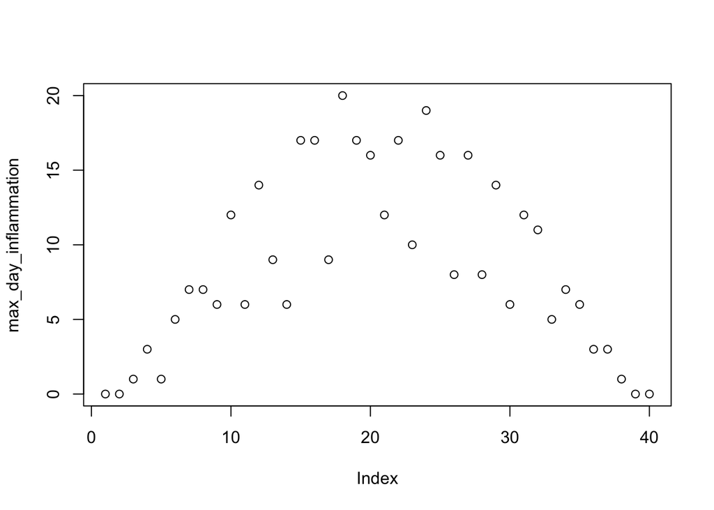

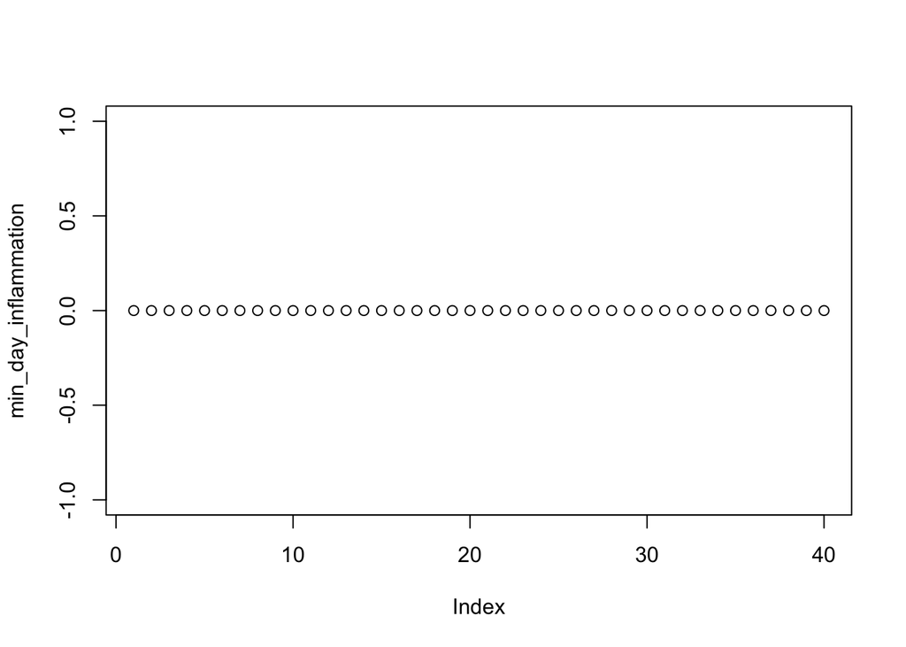

## Tip

> In this lesson we saw how to use a simple `for` loop to repeat an operation. As you progress with R, you will learn that there are multiple ways to accomplish this. Sometimes the choice of one method over another is more a matter of personal style, but other times it can have consequences for the speed of your code. For instruction on best practices, see this supplementary lesson that demonstrates how to properly repeat operations in R.

## Challenge - Using loops to analyze multiple files

> 1. Write a function called `analyze_all` that takes a filename pattern as its sole argument and runs `analyze` for each file whose name matches the pattern.

## Key Points

> - Use `for (variable in collection)` to process the elements of a collection one at a time.
> - The body of a `for` loop is surrounded by curly braces (`{ }`).
> - Use `length(thing)` to determine the length of something that contains other values.
> - Use `list.files(path = "path", pattern = "pattern", full.names = TRUE)` to create a list of files whose names match a pattern.

## Next Steps

> We have now solved our original problem: we can analyze any number of data files with a single command. More importantly, we have met two of the most important ideas in programming:
> - Use functions to make code easier to re-use and easier to understand.
> - Use vectors and data frames to store related values, and loops to repeat operations on them.

> We have one more big idea to introduce…